# Power analysis for smallest effect size

## Simulating the CF peak frequency data

```python
def include_measurement_accuracy(X, measurement_accuracy):
    '''
    '''
    return np.array([return_rounded_output(each, measurement_accuracy) for each in X])

def return_rounded_output(each, measurement_accuracy):
    remainder = np.remainder(each, measurement_accuracy)
    if remainder/measurement_accuracy < 0.5:
        return measurement_accuracy*int(each/measurement_accuracy)
    elif remainder/measurement_accuracy >=0.5:
        return measurement_accuracy*(int(each/measurement_accuracy)+1)
```

### We will *not* be including separate modelling of Doppler shifts because the analysed CF peak frequencies already result from a variety of emitted CFs and bat flight speeds.

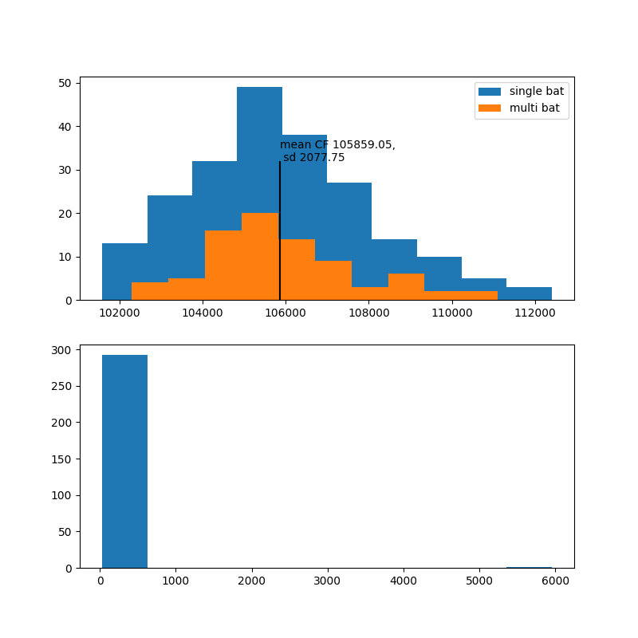

```python
mean_cf_peak = np.round(np.mean(df['cf_peak_frequency']),2);
sd_cf_peak = np.round(np.std(df['cf_peak_frequency']),2)

plt.figure(figsize=(8,8))
plt.subplot(211)
plt.hist(single_bat['cf_peak_frequency'], label='single bat');
plt.hist(multi_bat['cf_peak_frequency'], label='multi bat');
plt.vlines(mean_cf_peak, 0,32); plt.text(mean_cf_peak, 32, f'mean CF {mean_cf_peak}, \n sd {sd_cf_peak}')

plt.legend()
plt.subplot(212)
plt.hist(df['cf_peak_freq_resolution']);
```

### Now, lets simulate a case where bats begin to emit *higher* frequencies, by 2 kHz when in groups. Will our tests be able to pick that up?

```python
freq_shifts = np.arange(0,6)
results_significant = []

max_freq_resoln = 600

for shift in [0, 2000]:
    for i in tqdm(range(num_trials)):
        # need to parametrise this stuff to the experimental data
        solitary_bat_pf = np.random.normal(mean_cf_peak, sd_cf_peak, single_sample_size)
        solitary_bat_pf = include_measurement_accuracy(solitary_bat_pf, max_freq_resoln)

        group_bat_pf = np.random.normal(mean_cf_peak + shift, sd_cf_peak, group_sample_size)
        group_bat_pf = include_measurement_accuracy(group_bat_pf, max_freq_resoln)

        data_overlap, outputs, shuffled_overlaps = shuffle_overlap.overlap_w_shuffling(solitary_bat_pf,
                                                                                       group_bat_pf
                                                                                      ,num_shuffles=N_shuffles)
        observed_percentile = shuffle_overlap.percentile_score_of_value(data_overlap, shuffled_overlaps)

        result_significant = observed_percentile < alpha
        results_significant.append(result_significant)
```

```python
true_negative_rate = 1 - sum(results_significant[:num_trials])/num_trials
power = sum(results_significant[num_trials:])/num_trials

print(true_negative_rate, power)
```

```
0.99 1.0
```

## Parametrising tFM durations in the raw data

```python
import scipy.stats as stats
```

```python
stats.kstest(df['tfm_duration'].dropna(), 'norm')
```

```
KstestResult(statistic=0.5001260657585088, pvalue=1.5824600932972944e-68)
```

The raw data doesn't strictly fit the normal distribution (KS-test results above). I still think the overall match is visible, and so am going ahead and modelling the simulated data as a normal distribution.

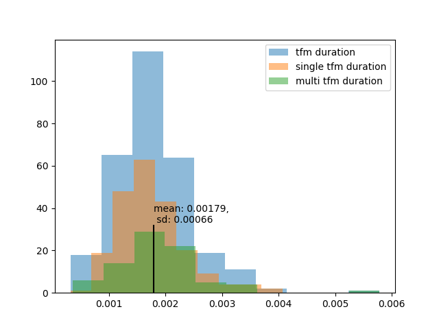

```python
mean_tfm_durn = np.mean(df['tfm_duration'])
sd_tfm_durn = np.std(df['tfm_duration'])
plt.figure()
plt.hist(df['tfm_duration'], alpha=0.5, label='tfm duration')
plt.hist(single_bat['tfm_duration'], alpha=0.5, label='single tfm duration')
plt.hist(multi_bat['tfm_duration'], alpha=0.5, label='multi tfm duration')
plt.vlines(mean_tfm_durn, 0, 32)
plt.text(mean_tfm_durn, 33, f'mean: {np.round(mean_tfm_durn, 5)}, \n sd: {np.round(sd_tfm_durn, 5)}')
plt.legend()
```

### Power to pick up changes in FM durations by 25%

```python
results_significant = []
fm_duration_accuracy = 0.1*10**-3 # assumed duration measurement accuracy

fm_change = [1, 0.75, 1.25]

all_obs_pctile = []
for change in fm_change:
    for i in tqdm(range(num_trials)):
        # need to parametrise this stuff to the experimental data
        solitary_bat_pf = np.random.normal(mean_tfm_durn, sd_tfm_durn, single_sample_size) # in ms
        solitary_bat_pf = include_measurement_accuracy(solitary_bat_pf, fm_duration_accuracy)

        group_bat_pf = np.random.normal(mean_tfm_durn*change,sd_tfm_durn, group_sample_size) # in ms
        group_bat_pf = include_measurement_accuracy(group_bat_pf, fm_duration_accuracy)

        data_overlap, outputs, shuffled_overlaps = shuffle_overlap.overlap_w_shuffling(solitary_bat_pf,
                                                                                       group_bat_pf
                                                                                      ,num_shuffles=N_shuffles)
        observed_percentile = shuffle_overlap.percentile_score_of_value(data_overlap, shuffled_overlaps)

        # The overlap is always expected to be low if the distributions are different - and so check for
        # this.
        result_significant = observed_percentile < alpha
        results_significant.append(result_significant)
        all_obs_pctile.append(observed_percentile)
    power = sum(results_significant)/num_trials
    print(power)

overall_power = sum(results_significant)/len(fm_change)*num_trials
```

```
0.01
```

```
0.88
```

```
1.72
```

```python
true_negative_rate = 1 - sum(results_significant[:num_trials])/num_trials
power = sum(results_significant[num_trials:])/len(results_significant[num_trials:])

print(true_negative_rate, power)
```

```
0.99 0.855
```

## Power to pick up call duration changes

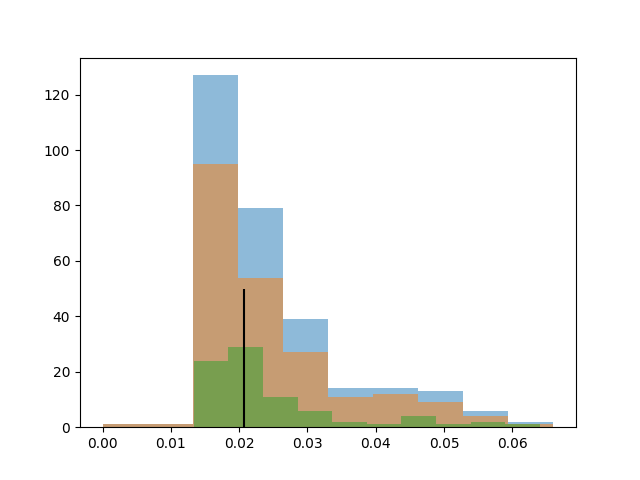

```python
median_durn = np.median(df['whole_call_duration'])

plt.figure()
plt.hist(df['whole_call_duration'], alpha=0.5);
plt.hist(single_bat['whole_call_duration'], alpha=0.5);
plt.hist(multi_bat['whole_call_duration'], alpha=0.5);
plt.vlines(median_durn,0,50)
```

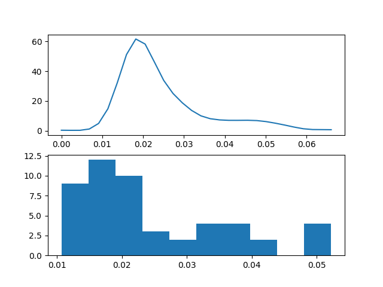

```python
kde_wholecall = shuffle_overlap.generate_kde(df['whole_call_duration'])

call_durns = np.linspace(np.min(df['whole_call_duration']), np.max(df['whole_call_duration']), 30)

pdf = kde_wholecall.evaluate(call_durns)

res = kde_wholecall.resample(50)

plt.figure()
plt.subplot(211)
plt.plot(call_durns, pdf)

plt.subplot(212)
plt.hist(res.flatten());
```

```python
call_duration_accuracy = 0.1*10**-3 # assumed duration measurement accuracy
shift_factor  = 0.26 # 3 %
call_duration_change = [1, -shift_factor, +shift_factor]
results_significant = []
for change in call_duration_change:
    for i in tqdm(range(num_trials)):
        # need to parametrise this stuff to the experimental data


        solitary_bat_pf = kde_wholecall.resample(single_sample_size).flatten() # in ms
        solitary_bat_pf = include_measurement_accuracy(solitary_bat_pf, fm_duration_accuracy)

        multi_kde = shuffle_overlap.generate_kde(df['whole_call_duration'])
        group_bat_pf = multi_kde.resample(group_sample_size)
        if change != 1:
            group_bat_pf += change*np.mean(df['whole_call_duration'])

        group_bat_pf = include_measurement_accuracy(group_bat_pf.flatten(), fm_duration_accuracy)

        data_overlap, outputs, shuffled_overlaps = shuffle_overlap.overlap_w_shuffling(solitary_bat_pf,
                                                                                       group_bat_pf,
                                                                                      num_shuffles=N_shuffles)
        observed_percentile = shuffle_overlap.percentile_score_of_value(data_overlap, shuffled_overlaps)

        significance = observed_percentile < alpha
        results_significant.append(significance)
    power = sum(results_significant)/num_trials
    print(power)

overall_power = sum(results_significant)/len(fm_change*num_trials)
```

```
0.0
```

```
0.99
```

```
1.95
```

```python
true_negative_rate = 1 - sum(results_significant[:num_trials])/num_trials
power = sum(results_significant[num_trials:])/len(results_significant[num_trials:])

print(true_negative_rate, power)
```

```
1.0 0.975
```

### References

1. Lakens, Daniel, Observed power, and what to do if your editor asks for post-hoc power analyses, blog-post. Accessed from http://daniellakens.blogspot.com/2014/12/observed-power-and-what-to-do-if-your.html on 19-06-2020
2. Zhang Y, Hedo R, Rivera A, et al, Post hoc power analysis: is it an informative and meaningful analysis? General Psychiatry 2019;32:e100069. doi: 10.1136/gpsych-2019-100069
3. Fawcett, K., Jacobs, D. S., Surlykke, A., & Ratcliffe, J. M. (2015). Echolocation in the bat, Rhinolophus capensis: the influence of clutter, conspecifics and prey on call design and intensity. Biology Open, 4(6), 693-701.
4. di Stephano, J. (2003). How much power is enough? Against the development of an arbitrary convention for statistical power calculations. Functional Ecology, 17(5), 707-709.

```python
import datetime as dt
dt.datetime.now()
```

```
datetime.datetime(2020, 7, 3, 13, 12, 5, 138128)
```